# Topic 1, Part 2: Introduction to Jupyter Notebook

Remember, Python is the programming language; Jupyter Notebook is the Integrated Development Environment (IDE)!

### Types of cells

#### Code Cells

In these cells you put your Python Code

You will recognise them easily, as they have `In []` next to them

```python
1+1
```

```
2
```

#### Markdown Cells

In these cells you can write comments, section headers, or even import some media!

Since you will be presenting your coursework as a Jupyter Notebook, I recommend you to have a very good idea of how to use the Markdown cells

You can check [this post](https://medium.com/analytics-vidhya/the-ultimate-markdown-guide-for-jupyter-notebook-d5e5abf728fd) for the "ultimate" guide on how to use markdown

### Keyboard Shortcuts

Having an idea of the shortcuts will help you produce notebooks faster!

Check your shortcuts in Help $\rightarrow$ Keyboard Shortcuts

For instance, you can press "B" and add a cell below, instead of having to click in the options above or below this cell

## Loading images/videos into a Jupyter Notebook

Images from your local drive (using a Markdown cell):

1. Store the image **in the same directory as the notebook**
2. Use "!", then put a text inside squared brackets "[]" for reference, and parenthesis "()" for the file name

[figure not shown]

If you prefer, you can create a subdirectory for all of your images:

[figure not shown]

Inserting an image online (make sure you have access always)

[figure not shown]

Loading an image AS DATA, you can use packages such as `OpenCV` or `Pillow` (we will use this a lot during the module!)

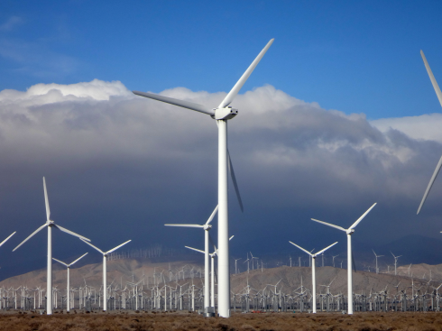

```python
# This cell will work only if the image is in the same directory as this notebook
from PIL import Image
im = Image.open("Wind_turbines_in_southern_California.png")
im
```

```python
# the variable im contains the pixels of the image
im.size
```

```
(490, 367)
```

**Inserting a YouTube Video:**

```
1. Go to YouTube
2. Under "Share" select embed
3. You will get an html code, copy it inside the following Python code

    from IPython.display import HTML
    HTML('embed html code here')
```

```python
import warnings;
warnings.simplefilter('ignore')
from IPython.display import HTML
HTML('<iframe width="560" height="315" src="https://www.youtube.com/embed/r-uOLxNrNk8" frameborder="0" allow="accelerometer; autoplay; clipboard-write; encrypted-media; gyroscope; picture-in-picture" allowfullscreen></iframe>')
```

[video not shown]

## Loading data into a Jupyter Notebook

Just as we loaded the wind farm image as data before, you must know that we can load data from different extensions (.csv, .tsv, .txt, .xlsx) to our notebooks!

The easiest way to do so is with a Python module called `Pandas`

```python
import pandas as pd
```

```python
# This cell will work only if the "data.csv" is in the same directory as this notebook
data = pd.read_csv('data.csv')
data
```

|  | Name | Age | Height |
| --- | --- | --- | --- |
| 0 | Nick | 21 | 1.85 |
| 1 | Chris | 29 | 1.79 |
| 2 | Tim | 28 | 1.75 |
| 3 | Ron | 34 | 1.81 |
| 4 | Monica | 35 | 1.69 |
| 5 | Cassandra | 21 | 1.66 |

Commands such as `read_csv` can also take a web address as an input, and load images from online repos!

For instance, if `data.csv` is in my [Dropbox](https://www.dropbox.com/), I can copy the dropbox link, change `dl=0` for `raw=1` and load the file

```python
# This command will run anywhere (as long as you have internet connection)
data_dropbox = pd.read_csv('https://www.dropbox.com/s/my97tgyus8s05e1/data.csv?raw=1')
data_dropbox
```

|  | Name | Age | Height |
| --- | --- | --- | --- |
| 0 | Nick | 21 | 1.85 |
| 1 | Chris | 29 | 1.79 |
| 2 | Tim | 28 | 1.75 |
| 3 | Ron | 34 | 1.81 |
| 4 | Monica | 35 | 1.69 |
| 5 | Cassandra | 21 | 1.66 |

## Online Jupyter Notebooks

We will use **Google Colab** as an alternative!

https://colab.research.google.com/drive/1R-xx9LbFl4kdG5IqxqeYuNPb1O1hDZ66?usp=sharing

# "Lab 1": Installing Python & Jupyter Notebook (or Anaconda) + Signing up for Colab